# Processing_Updated

Paige Duffin

11/3/2019

```r
library(caret) # Classification and Regression Training
```

```r
library(corrplot)
library(dplyr) # A Grammar of Data Manipulations
library(forcats) # Tools for Working with Categorical Variables (Factors)
library(gdata) # Various R Programming Tools for Data Manipulation
library(ggplot2) # Create Elegant Data Visualizations Using the Grammar of Graphics
library(ggrepel) # Automatically Position Non-Overlapping Text Labels with ‘ggplot2’
library(ggridges) # Ridgeline Plots in ‘ggplot2’
library(ggthemes) # Extra Themes, Scales, and Geoms for ‘ggplot2’
library(gmodels) # Various R Programming Tools for Model Fitting
library(grid) # The Grid Graphics Package
library(gridExtra)
library(knitr) # A General-Purpose Package for Dynamic Report Generation in R
library(lmtest) # Testing Linear Regression Models
library(plyr) # Tools for Splitting, Applying and Combining Data
library(purrr) # Functional Programming Tools
library(readr) # Read Rectangular Text Data
library(rpart)
library(rattle)
library(scales) # Scale Functions for Visualization
library(shiny) # Web Application Framework for R
library(skimr) # Compact and Flexible Summaries of Data
library(stringr) # Simple, Consistent Wrappers for Common String Operations
library(tibble) # Simple Data Frames
library(tidyr) # Easily Tidy Data with ‘spread()’ and ‘gather()’ Functions
library(tidyverse) # Install and Load ‘Tidyverse’ Packages
library(usmap)
library(rworldmap)
library(ggmap)
library(maps)
library(mapdata)
library(cowplot)
library("googleway")
library("ggspatial")
library("rnaturalearth")
library("rnaturalearthdata")
theme_set(theme_bw())
library("sf")
raw_SS_count <- read.csv("../../data/raw_data/seastarkat_size_count_totals_download.csv")
SS_count <- raw_SS_count
```

```r
SS_count$group_code <- as.character(SS_count$group_code)
SS_count$site_code <- as.character(SS_count$site_code)
SS_count$marine_site_name <- as.character(SS_count$marine_site_name)
SS_count$marine_season_code <- as.character(SS_count$marine_season_code)
SS_count$season_name <- as.character(SS_count$season_name)
SS_count$target_assemblage <- as.character(SS_count$target_assemblage)
SS_count$method_code <- as.character(SS_count$method_code)
SS_count$species_code <- as.character(SS_count$species_code)
SS_count$mpa_designation <- as.character(SS_count$mpa_designation)
SS_count$mpa_region <- as.character(SS_count$mpa_region)
SS_count$georegion <- as.character(SS_count$georegion)
SS_count$bioregion <- as.character(SS_count$bioregion)
SS_count$state_province <- as.character(SS_count$state_province)
SS_count$island <- as.character(SS_count$island)
SS_count$last_updated <- as.character(SS_count$last_updated)
glimpse(SS_count)
```

```
## Observations: 13,165
## Variables: 24
## $ group_code           <chr> "UCLA", "UCLA", "UCLA", "UCLA", "UCLA", "UC…
## $ site_code            <chr> "ALEG", "ALEG", "ALEG", "ALEG", "ALEG", "AL…
## $ marine_site_name     <chr> "Alegria", "Alegria", "Alegria", "Alegria",…
## $ marine_sort_order    <int> 6420, 6420, 6420, 6420, 6420, 6420, 6420, 6…
## $ latitude             <dbl> 34.46714, 34.46714, 34.46714, 34.46714, 34.…
## $ longitude            <dbl> -120.2774, -120.2774, -120.2774, -120.2774,…
## $ marine_common_season <int> 85, 85, 85, 85, 85, 85, 85, 85, 85, 85, 85,…
## $ marine_season_code   <chr> "SP02", "SP02", "SP02", "SP02", "SP02", "SP…
## $ marine_common_year   <int> 2002, 2002, 2002, 2002, 2002, 2002, 2002, 2…
## $ season_sequence      <int> 1, 1, 1, 1, 1, 1, 1, 1, 1, 1, 1, 1, 1, 1, 1…
## $ season_name          <chr> "Spring", "Spring", "Spring", "Spring", "Sp…
## $ target_assemblage    <chr> "sea_star", "sea_star", "sea_star", "sea_st…
## $ method_code          <chr> "IP", "IP", "IP", "IP", "IP", "IP", "IP", "…
## $ species_code         <chr> "PISOCH", "PISOCH", "PISOCH", "PISOCH", "PI…
## $ size_sort_order      <int> 3, 4, 5, 6, 7, 8, 9, 10, 11, 12, 14, 15, 16…
## $ size_bin             <int> 20, 30, 40, 50, 60, 70, 80, 90, 100, 110, 1…
## $ total                <int> 1, 3, 16, 25, 27, 22, 11, 2, 2, 1, 1, 3, 6,…
## $ mpa_designation      <chr> "reference", "reference", "reference", "ref…
## $ mpa_region           <chr> "South Coast", "South Coast", "South Coast"…
## $ georegion            <chr> "CA South", "CA South", "CA South", "CA Sou…
## $ bioregion            <chr> "Government Point to Mexico", "Government P…
## $ state_province       <chr> "California", "California", "California", "…
## $ island               <chr> "Mainland", "Mainland", "Mainland", "Mainla…
## $ last_updated         <chr> "2019-04-05 20:07:59", "2019-04-05 20:07:59…
```

```r
skim(SS_count)
```

```
## Skim summary statistics
##  n obs: 13165
##  n variables: 24
##
## ── Variable type:character ─────────────────────────────────────────
##            variable missing complete     n min max empty n_unique
##           bioregion       0    13165 13165  13  33     0        6
##           georegion       0    13165 13165   2  24     0        9
##          group_code       0    13165 13165   2   6     0        9
##              island       0    13165 13165   3   9     0        7
##        last_updated       0    13165 13165  19  19     0        1
##  marine_season_code       0    13165 13165   4   4     0       57
##    marine_site_name       0    13165 13165   5  42     0       77
##         method_code       0    13165 13165   2   4     0        4
##     mpa_designation       0    13165 13165   2   9     0        5
##          mpa_region       0    13165 13165   2  19     0        6
##         season_name       0    13165 13165   4   6     0        4
##           site_code       0    13165 13165   3   4     0       77
##        species_code       0    13165 13165   6   6     0        3
##      state_province       0    13165 13165   6  10     0        4
##   target_assemblage       0    13165 13165   8   8     0        1
##
## ── Variable type:integer ───────────────────────────────────────────
##              variable missing complete     n    mean      sd   p0  p25
##  marine_common_season       0    13165 13165  116.82   19.23   78  101
##    marine_common_year       0    13165 13165 2009.7     4.81 2000 2006
##     marine_sort_order       0    13165 13165 5566.24 1125.15 1720 5020
##       season_sequence       0    13165 13165    2.03    0.81    1    1
##              size_bin       0    13165 13165   82.44   42.2     5   50
##       size_sort_order       0    13165 13165    9.57    4.15    1    6
##                 total       0    13165 13165    9.92   16.43    1    2
##   p50  p75 p100     hist
##   118  131  152 ▅▅▆▇▇▇▇▅
##  2010 2013 2018 ▃▅▅▇▇▆▆▆
##  6090 6370 7650 ▁▁▁▂▃▃▇▁
##     2    3    4 ▇▁▇▁▁▇▁▁
##    80  110  320 ▅▇▇▃▁▁▁▁
##    10   12   33 ▅▇▇▃▁▁▁▁
##     4   11  360 ▇▁▁▁▁▁▁▁
##
## ── Variable type:numeric ───────────────────────────────────────────
##   variable missing complete     n    mean   sd      p0     p25     p50
##   latitude       0    13165 13165   38.67 5.2    32.87   34.73   36.62
##  longitude       0    13165 13165 -122.25 2.86 -135.38 -123.98 -121.94
##      p75    p100     hist
##    41.65   57.05 ▇▆▃▂▁▁▁▁
##  -120.62 -117.25 ▁▁▁▁▅▇▆▃
```

View all variables

```r
names(SS_count)
```

```
##  [1] "group_code"           "site_code"            "marine_site_name"
##  [4] "marine_sort_order"    "latitude"             "longitude"
##  [7] "marine_common_season" "marine_season_code"   "marine_common_year"
## [10] "season_sequence"      "season_name"          "target_assemblage"
## [13] "method_code"          "species_code"         "size_sort_order"
## [16] "size_bin"             "total"                "mpa_designation"
## [19] "mpa_region"           "georegion"            "bioregion"
## [22] "state_province"       "island"               "last_updated"
```

Examine each variable- characters first

```r
unique(SS_count$group_code)
```

```
## [1] "UCLA"   "UCSC"   "UCSB"   "CSUF"   "FEIRO"  "OCNMS"  "PBNERR" "UW"
## [9] "SSSC"
```

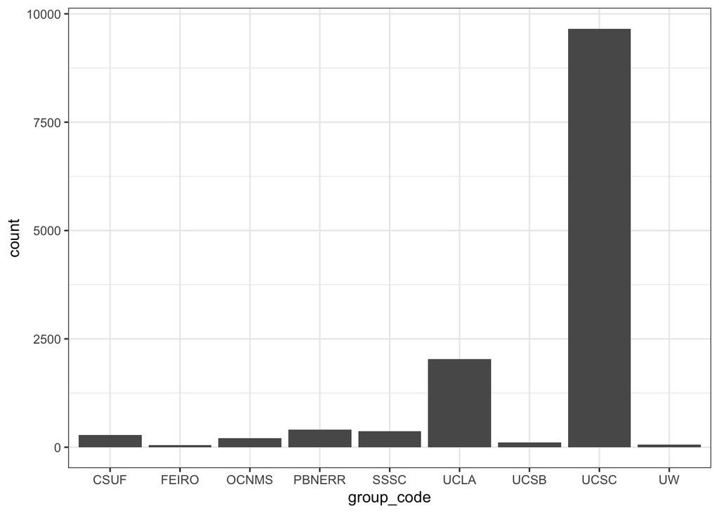

```r
group_code_histogram <- SS_count %>% ggplot2::ggplot() + geom_bar(aes(group_code))
group_code_histogram
```

```r
ggsave(filename = "../../results/Processing_results/group_code_histogram.png",plot = group_code_histogram, width = 5, height = 4)
```

Hmmm, very biased towards UCSC. Maybe I should make an additional group_code that is UCSC vs Other

```r
SS_count1 <- SS_count %>% mutate(group_code_UCSC_other = recode(group_code, "CSUF" = "Other", "FEIRO" = "Other", "OCNMS" = "Other", "PBNERR" = "Other", "SSSC" = "Other", "UCLA" = "Other", "UCSB" = "Other", "UW" = "Other"))
skim(SS_count1$group_code_UCSC_other)
```

```
##
## Skim summary statistics
##
## ── Variable type:character ─────────────────────────────────────────
##                         variable missing complete     n min max empty
##  SS_count1$group_code_UCSC_other       0    13165 13165   4   5     0
##  n_unique
##         2
```

```r
SS_count1$group_code <- as.factor(SS_count1$group_code)
SS_count1$group_code_UCSC_other <- as.factor(SS_count1$group_code_UCSC_other)
```

Now `site_code`

```r
unique(SS_count1$site_code)
```

```
##  [1] "ALEG" "ARG"  "ARHO" "ARN"  "BML"  "BOA"  "BOB"  "BOD"  "BRN"  "CARP"
## [11] "CAY"  "CHM"  "COPT" "CRCO" "CTBR" "CTLH" "DAPT" "DAV"  "DEL"  "DMN"
## [21] "END"  "ESP"  "FKC"  "FOG"  "FRE"  "GAR"  "GER"  "GPT"  "GREN" "HATE"
## [31] "HATW" "HAZ"  "HOO"  "HOP"  "KAY"  "KIB"  "KYDI" "LOM"  "MAN"  "MCR"
## [41] "MEN"  "MOA"  "MOL"  "MUSH" "NAT"  "OCC"  "OLDS" "PBL"  "PCOV" "PHL"
## [51] "PIN"  "PIRA" "POP"  "PSN"  "PTFM" "PTL"  "PTVC" "SAGE" "SAU"  "SBNC"
## [61] "SBSE" "SCRE" "SCT"  "SEA"  "SHB"  "SHCO" "SHT"  "SIM"  "SOB"  "STA"
## [71] "STO"  "SWC"  "TPT"  "TRIS" "WHPT" "WIL"  "WIN"
```

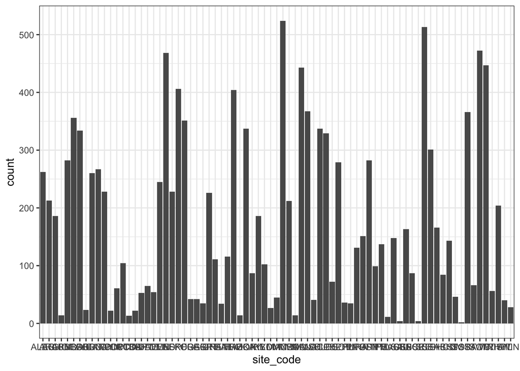

```r
SS_count1 %>% ggplot2::ggplot() + geom_bar(aes(site_code))
```

```r
SS_count2 <- SS_count1
SS_count2$site_code <- as.factor(SS_count1$site_code)
```

Now `marine_site_name`

```r
SS_count3 <- SS_count2
unique(SS_count3$marine_site_name)
```

```
##  [1] "Alegria"
##  [2] "Cape Arago"
##  [3] "Arroyo Hondo"
##  [4] "Point Arena"
##  [5] "Bodega"
##  [6] "Boat House"
##  [7] "Bob Creek"
##  [8] "Bodega Head"
##  [9] "Burnt Hill"
## [10] "Carpinteria"
## [11] "Cayucos"
## [12] "Chimney Rock"
## [13] "Coal Oil Point"
## [14] "Crystal Cove"
## [15] "Bird Rock"
```

[output cut: 62 more lines]

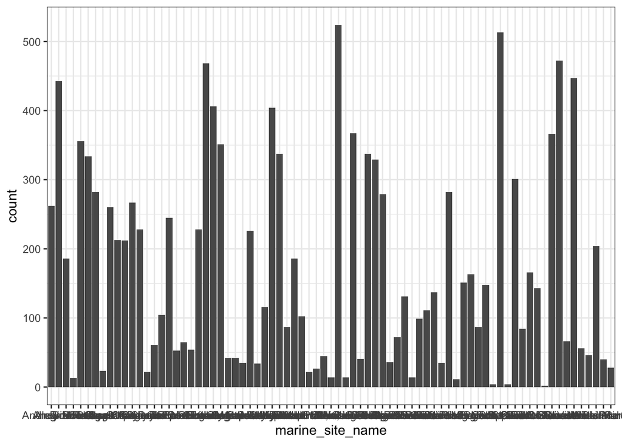

```r
SS_count3 %>% ggplot2::ggplot() + geom_bar(aes(marine_site_name))
```

```r
SS_count3$marine_site_name <- as.factor(SS_count3$marine_site_name)
```

One site name has a weird space after it- fixing that

```r
SS_count3 <- SS_count3 %>% mutate(marine_site_name = recode(marine_site_name, "McDonald Cove; Hood Canal " = "McDonald Cove; Hood Canal"))
#unique(SS_count3$marine_site_name) #double check to make sure that worked
SS_count3$marine_site_name <- as.factor(SS_count3$marine_site_name)
```

Now `marine_season_code`

```r
SS_count4 <- SS_count3
unique(SS_count4$marine_season_code)
```

```
##  [1] "SP02" "FA02" "SP03" "FA03" "SP04" "FA04" "SP05" "FA05" "SP06" "FA06"
## [11] "SP07" "FA07" "SP08" "FA08" "SP09" "FA09" "FA10" "SP11" "FA11" "SP12"
## [21] "FA12" "SP13" "FA13" "SP14" "FA14" "SP15" "SP16" "FA16" "SP17" "FA17"
## [31] "SU01" "SU02" "SU03" "SU04" "SU05" "SU06" "SU07" "SU08" "SU10" "SU11"
## [41] "SU12" "SU13" "SU14" "SU15" "SU16" "SU17" "SU18" "FA00" "SP01" "FA01"
## [51] "SP10" "FA18" "SU09" "FA15" "SU00" "SP18" "WN18"
```

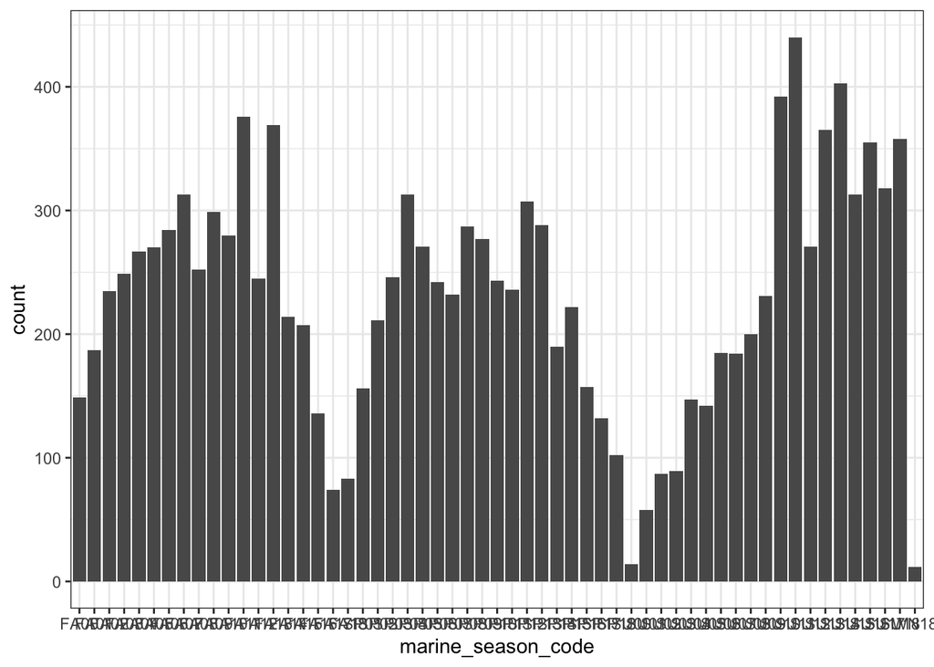

```r
SS_count4 %>% ggplot2::ggplot() + geom_bar(aes(marine_season_code))
```

```r
SS_count4$marine_season_code <- as.factor(SS_count4$marine_season_code)
```

Kinda weird to have this var, when this info is already contained in the `season_name`, and `marine_common_year` vars, but it could be useful, and there appear to be no issues with it, so I’ll leave it for now…..

Well, it does show information in this graph that is very interesting and allows for a timeline at a finer scale than by year. Actually, this looks very informative!

Now `season_name`

```r
SS_count5 <- SS_count4
unique(SS_count5$season_name)
```

```
## [1] "Spring" "Fall"   "Summer" "Winter"
```

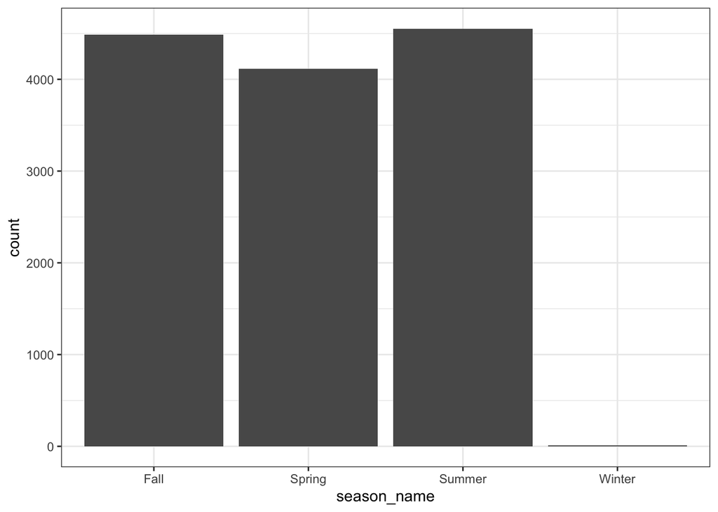

```r
SS_count5 %>% ggplot2::ggplot() + geom_bar(aes(season_name))
```

```r
SS_count5$season_name <- as.factor(SS_count5$season_name)
```

Now `target_assemblage`

```r
SS_count6 <- SS_count5
unique(SS_count6$target_assemblage)
```

```
## [1] "sea_star"
```

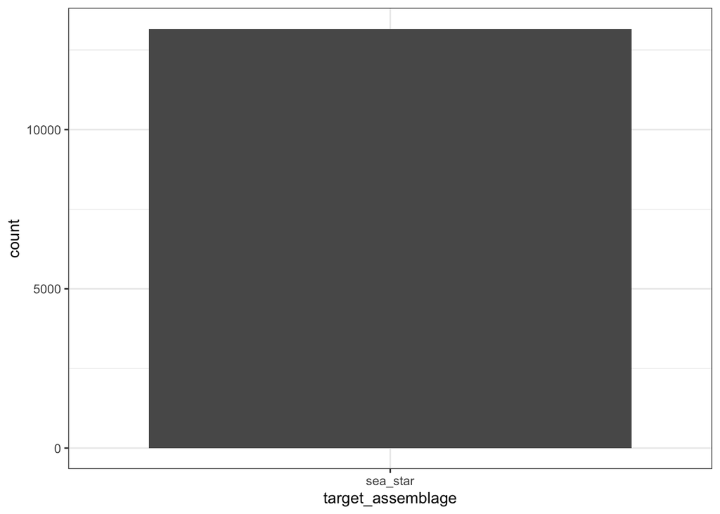

```r
SS_count6 %>% ggplot2::ggplot() + geom_bar(aes(target_assemblage))
```

Okay, so this analysis revealed that this variable is completelly uninformative, because its always the same target. Deleting this variable.

```r
SS_count6 <- SS_count6[-c(12)]
#names(SS_count6) #just checking
```

Now `method_code`

```r
SS_count7 <- SS_count6
unique(SS_count7$method_code)
```

```
## [1] "IP"   "BT25" "GSES" "TS30"
```

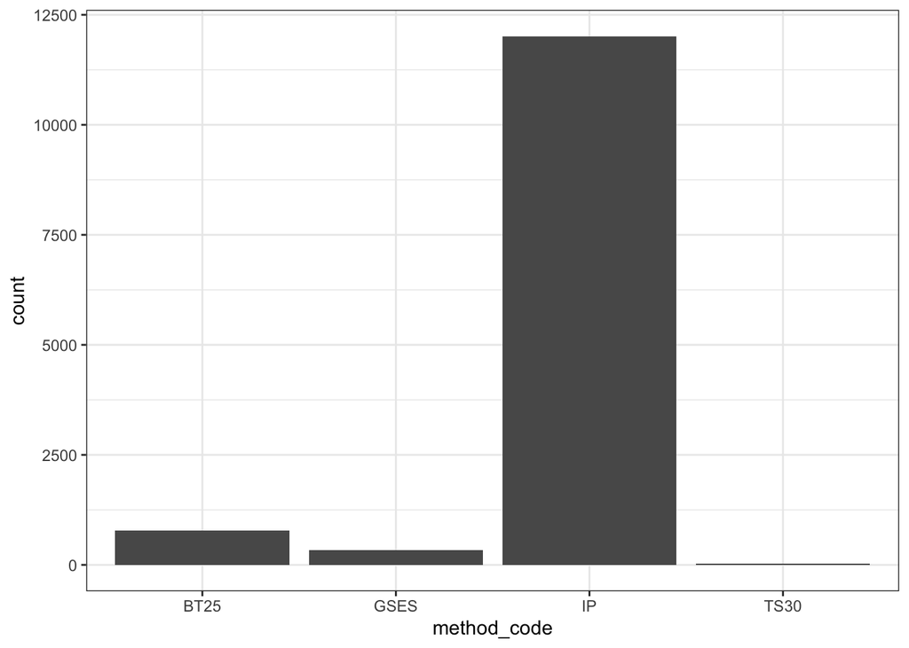

```r
SS_count7 %>% ggplot2::ggplot() + geom_bar(aes(method_code))
```

Same story as `group_code`… very disproportionate. Doing the same thing as before- adding a new variable that is the most common method () vs “Other”

```r
SS_count7 <- SS_count7 %>% mutate(method_code_IP_other = recode(method_code, "TS30" = "Other", "GSES" = "Other", "BT25" = "Other"))
skim(SS_count7$method_code_IP_other)
```

```
##
## Skim summary statistics
##
## ── Variable type:character ─────────────────────────────────────────
##                        variable missing complete     n min max empty
##  SS_count7$method_code_IP_other       0    13165 13165   2   5     0
##  n_unique
##         2
```

```r
SS_count7$method_code_IP_other <- as.factor(SS_count7$method_code_IP_other)
SS_count7$method_code <- as.factor(SS_count7$method_code)
```

Now `mpa_designation`

```r
SS_count8 <- SS_count7
unique(SS_count8$mpa_designation)
```

```
## [1] "reference" "NULL"      "SMR"       "MR"        "SMCA"
```

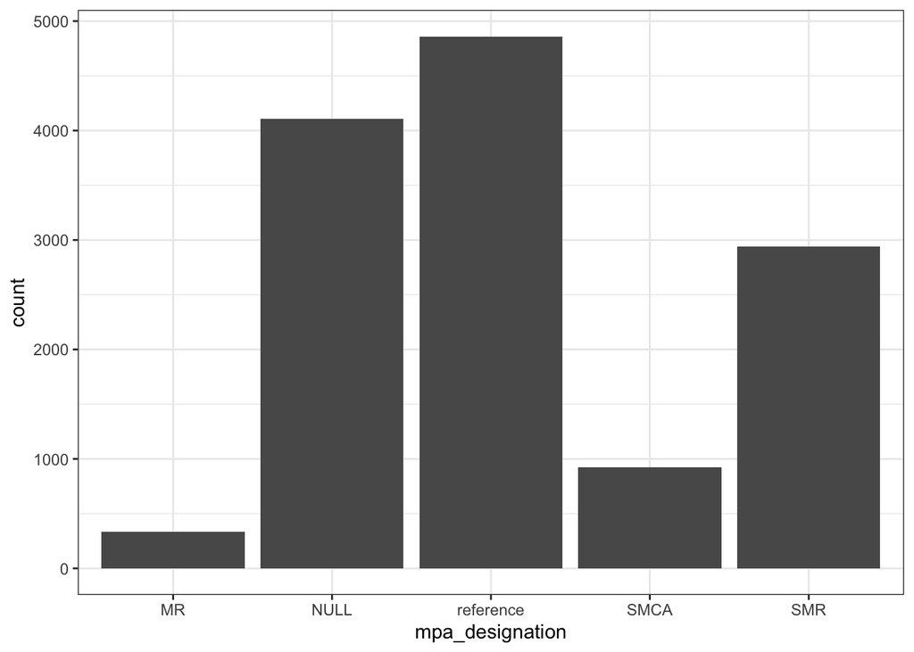

```r
SS_count8 %>% ggplot2::ggplot() + geom_bar(aes(mpa_designation))
```

These designations aren’t intuitive… let me see what the code says.. > `mpa_designation`: Describes whether the referenced site is located within a Marine Protected Area (MPA) or is a reference site. If this field is blank, the referenced site is not located within an MPA, or is not a reference site for an existing MPA site.

That doesn’t really help me understand these levels because I don’t know what a reference site is (even after a Google investigation). If this ends up being an important predictor in my model later, I will try to understand better what these categories mean.

Changing to a factor and moving on.

```r
SS_count8$mpa_designation <- as.factor(SS_count8$mpa_designation)
```

Now `mpa_region`

```r
SS_count9 <- SS_count8
unique(SS_count9$mpa_region)
```

```
## [1] "South Coast"         "NULL"                "North Central Coast"
## [4] "Central Coast"       "OR"                  "North Coast"
```

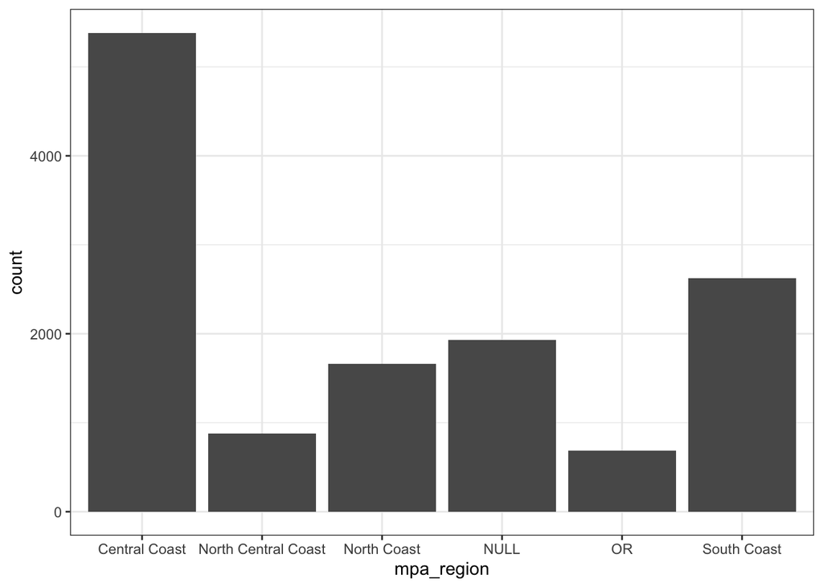

```r
SS_count9 %>% ggplot2::ggplot() + geom_bar(aes(mpa_region))
```

Shouldn’t the number of `NULL` entries in this variable (`mpa_region`) match the number of `NULL` entries in the last variable I looked at (`mpa_designation`)? What’s going on?

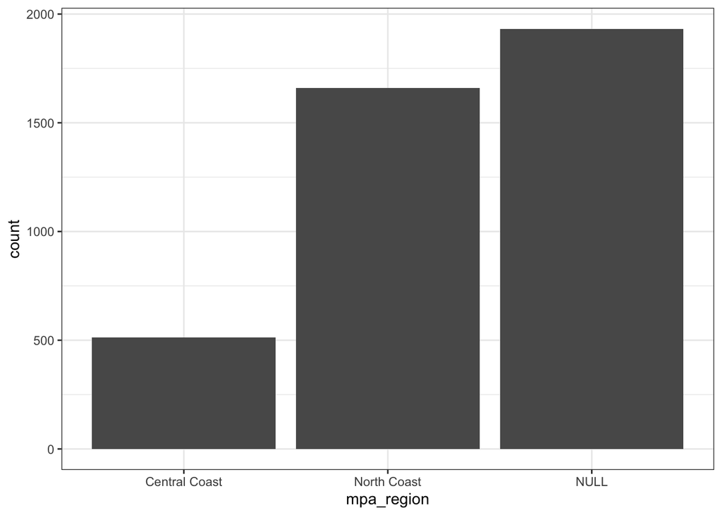

```r
NULL_mpa_designation <- SS_count9 %>% select(names(SS_count9)) %>% filter(mpa_designation == "NULL")
NULL_mpa_designation %>% ggplot2::ggplot() + geom_bar(aes(mpa_region))
```

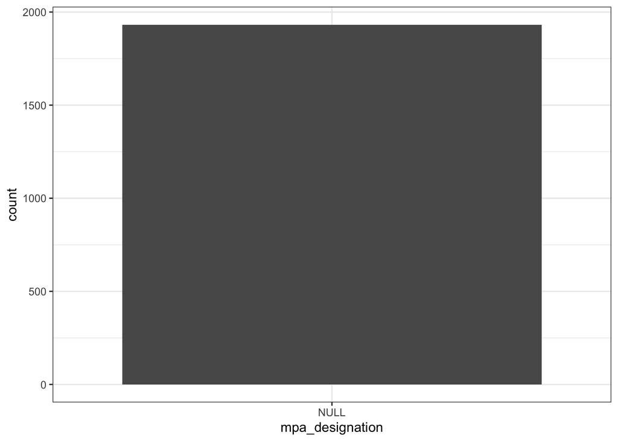

```r
NULL_mpa_region <- SS_count9 %>% select(names(SS_count9)) %>% filter(mpa_region == "NULL")
NULL_mpa_region %>% ggplot2::ggplot() + geom_bar(aes(mpa_designation))
```

I don’t understand why some of the values for `mpa_designation` are labeled as not associated with an MPA (`NULL`) but their corresponding `mpa_region` is associated with a region.

Because I see that all “NULL” `mpa_region`s are also “NULL” in the `mpa_designation` variable, but not all “NULL” `mpa_designations`s are also “NULL” in the `mpa_region` variable, it seems, at the very least, the `mpa_region` category is more informative. And, on top of that, these categories make sense to me, unlike those of the `mpa_designation` variable. Therefore, I’m making the decision to remove the `mpa_designation` variable from all downstream analyses. I have plenty of interesting variables to still work with (but if, for some reason, nothing is interesting in the models I run, I can always come back and add this variable back in, although it seems unlikely that `mpa_designation` would be an interesting predictor if I’d already determined that `mpa_region` weren’t).

Removing the `mpa_designation` variable and changing `mpa_region` to a factor.

```r
# names(SS_count9) # determined that `mpa_designation` var is column 17
SS_count10 <- SS_count9[-c(17)]
SS_count10$mpa_region <- as.factor(SS_count10$mpa_region)
# names(SS_count10) #just checking that it worked
```

Now `georegion`

```r
SS_count11 <- SS_count10
unique(SS_count11$georegion)
```

```
## [1] "CA South"                 "OR"
## [3] "CA North Central"         "CA Central"
## [5] "CA Channel Islands South" "CA North"
## [7] "WA Salish Sea"            "WA Olympic Coast"
## [9] "AK"
```

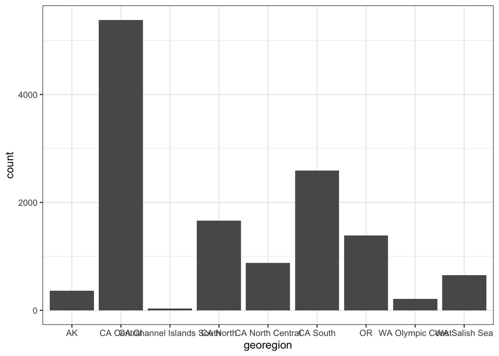

```r
SS_count11 %>% ggplot2::ggplot() + geom_bar(aes(georegion))
```

Very disproportionate.. but informative, and I don’t know of a way to make it more evenly spread.

```r
SS_count11$georegion <- as.factor(SS_count11$georegion)
```

Now `bioregion`

```r
SS_count12 <- SS_count11
unique(SS_count12$bioregion)
```

```
## [1] "Government Point to Mexico"        "WA Olympic Coast to San Francisco"
## [3] "San Francisco to Government Point" "Channel Islands South"
## [5] "WA Salish Sea"                     "Alaska to British Columbia"
```

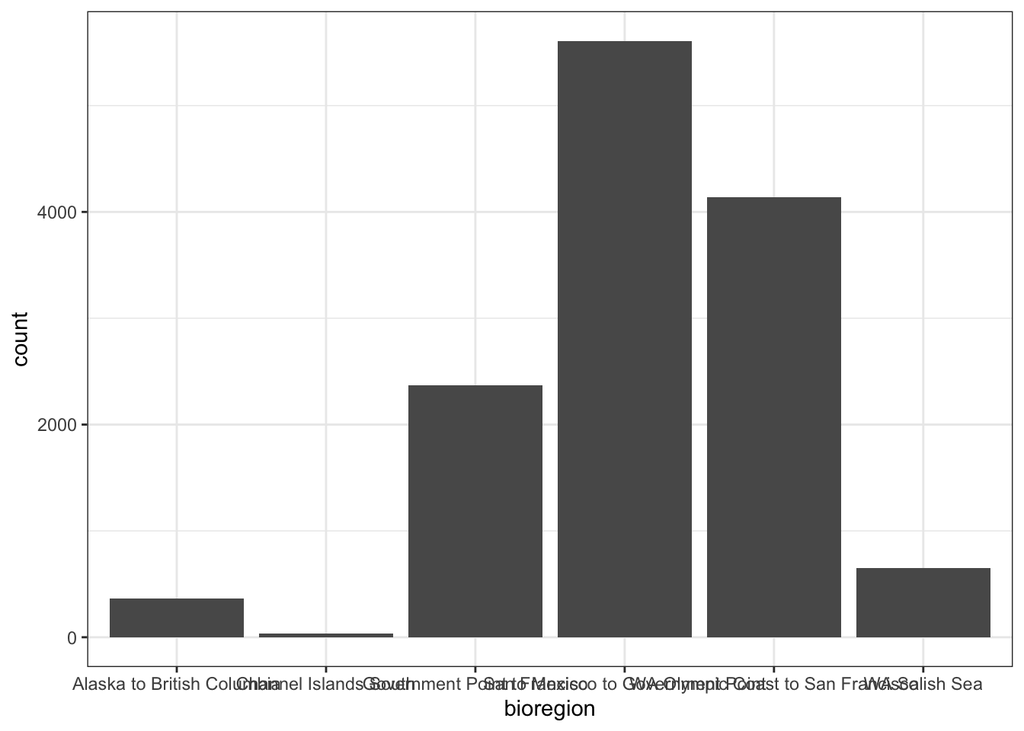

```r
SS_count12 %>% ggplot2::ggplot() + geom_bar(aes(bioregion))
```

Some of these names are really long.. I’m going to abbreviate where I can.

```r
SS_count12 <- SS_count12 %>% mutate(bioregion = recode(bioregion, "Government Point to Mexico" = "GovtPt_2_Mexico", "WA Olympic Coast to San Francisco" = "OlyCstWA_2_SanFran", "San Francisco to Government Point" = "SanFran_2_GovtPt", "Channel Islands South" = "ChannelIsl_South", "WA Salish Sea" = "SalishSea_WA", "Alaska to British Columbia" = "AK_2_BritColumb"))
# unique(SS_count12$bioregion) #double checking
SS_count12$bioregion <- as.factor(SS_count12$bioregion)
```

Now `state_province`

```r
SS_count13 <- SS_count12
unique(SS_count13$state_province)
```

```
## [1] "California" "Oregon"     "Washington" "Alaska"
```

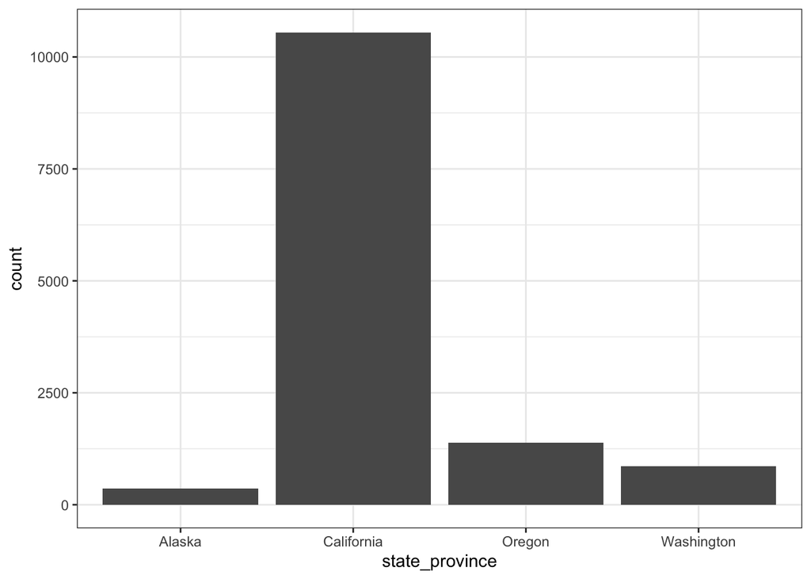

```r
SS_count13 %>% ggplot2::ggplot() + geom_bar(aes(state_province))
```

Just going to change these to the state abbreviations- personal preference. Also, there are no provinces in this variable, so renaming the variable to make more sense.

```r
SS_count13 <- SS_count13 %>% mutate(state = recode(state_province, "Alaska" = "AK", "Washington" = "WA", "Oregon" = "OR", "California" = "CA"))
#unique(SS_count13$state) #double checking
SS_count13$state <- as.factor(SS_count13$state)

# Removing old variable
# names(SS_count13) # determined that `state_province` var is column 20
SS_count14 <- SS_count13[-c(20)]
# names(SS_count14) #just checking that it worked
```

Now `island`

```r
SS_count15 <- SS_count14
unique(SS_count15$island)
```

```
## [1] "Mainland"  "Catalina"  "Hat"       "NULL"      "Kayak"     "Baranoff"
## [7] "Saddlebag"
```

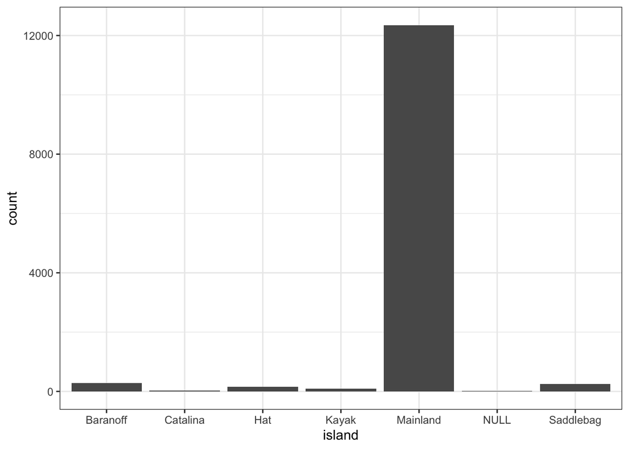

```r
SS_count15 %>% ggplot2::ggplot() + geom_bar(aes(island))
```

What does “NULL” mean in this situation?

```r
NULL_island <- SS_count15 %>% select(names(SS_count15)) %>% filter(island == "NULL")
NULL_island
```

```
##    group_code site_code          marine_site_name marine_sort_order
## 1          UW       HOO McDonald Cove; Hood Canal              3460
## 2          UW       HOO McDonald Cove; Hood Canal              3460
## 3          UW       HOO McDonald Cove; Hood Canal              3460
## 4          UW       HOO McDonald Cove; Hood Canal              3460
## 5          UW       HOO McDonald Cove; Hood Canal              3460
## 6          UW       HOO McDonald Cove; Hood Canal              3460
## 7          UW       HOO McDonald Cove; Hood Canal              3460
## 8          UW       HOO McDonald Cove; Hood Canal              3460
## 9          UW       HOO McDonald Cove; Hood Canal              3460
## 10         UW       HOO McDonald Cove; Hood Canal              3460
## 11         UW       HOO McDonald Cove; Hood Canal              3460
## 12         UW       HOO McDonald Cove; Hood Canal              3460
## 13         UW       HOO McDonald Cove; Hood Canal              3460
## 14         UW       HOO McDonald Cove; Hood Canal              3460
```

[output cut: 75 more lines]

```r
#NULL_mpa_designation %>% ggplot2::ggplot() + geom_bar(aes(mpa_region))
```

Its always at the same site: “McDonald Cove; Hood Canal” (site_code: “HOO”), so it must mean SOMETHING.. but what? Let me look at the documentation. It says, “The name of the island where the referenced site is located. Sites not on islands are designated as mainland.”

Okay, so there’s no good reason why this site has “NULL”. Let me see if there are entries at this site where it isn’t “NULL”.

```r
HOO_site <- SS_count15 %>% select(names(SS_count15)) %>% filter(site_code == "HOO")
unique(HOO_site$island)
```

```
## [1] "NULL"
```

Okay, so its only ever been “NULL” for this site in the `island` variable. I’ll have to figure out for myself if this site is on an island or not…. googling now…

Oh wow! Through this, I discovered the site that I downloaded this data from has detailed information on these collection sites… [here](https://marine.ucsc.edu/sitepages/mcdonaldcove.html). May use this information later… but for now, I used google maps to find this location. Its on the mainland- specifically on the Olympic Penninsula. Okay, cool. Mystery solved. Recoding it as “mainland.”

```r
SS_count15 <- SS_count15 %>% mutate(island = recode(island, "NULL" = "Mainland"))
unique(SS_count15$island)
```

```
## [1] "Mainland"  "Catalina"  "Hat"       "Kayak"     "Baranoff"  "Saddlebag"
```

```r
SS_count15$island <- as.factor(SS_count15$island)
```

Now `last_updated`

```r
SS_count16 <- SS_count15
unique(SS_count16$last_updated)
```

```
## [1] "2019-04-05 20:07:59"
```

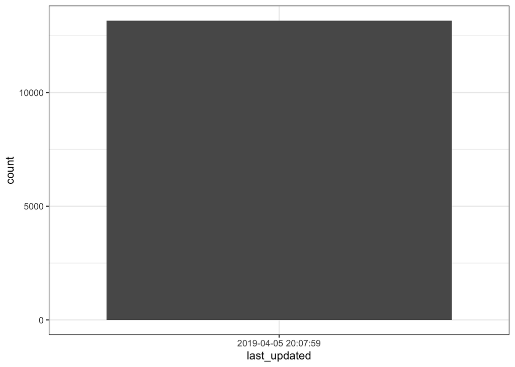

```r
SS_count16 %>% ggplot2::ggplot() + geom_bar(aes(last_updated))
```

Okay, as suspected, its completely uninformative as a future predictor variable. Removing it.

```r
# names(SS_count16) # determined that `last_updated` var is column 21
SS_count17 <- SS_count16[-c(21)]
# names(SS_count17) #just checking that it worked
```

## Integers

First, `marine_sort_order`. I don’t even know what this means, intuitively. What does the documentation say?

“Used to order the sites geographically along the coast. Actual values are arbitrary, and should not be used for site identification.”

Oh, interesting. That could actually be useful!

```r
SS_count18 <- SS_count17
unique(SS_count18$marine_sort_order)
```

```
##  [1] 6420 4600 6440 5100 5200 6390 4400 5210 4900 6480 6310 5230 6460 6660
## [15] 7610 7650 6740 6040 5140 5020 5010 4100 5030 4300 3850 6170 5170 6400
## [29] 3980 3290 3280 6320 3460 6090 1730 5070 3900 6380 3490 6220 5050 5120
## [43] 6190 6500 6080 6350 6520 6260 6580 5160 6100 1740 3080 6250 6620 6150
## [57] 6585 1720 5130 3260 3270 6780 6030 5150 6340 6680 5060 6280 6180 6370
## [71] 5110 6130 6070 6720 6600 6060 5180
```

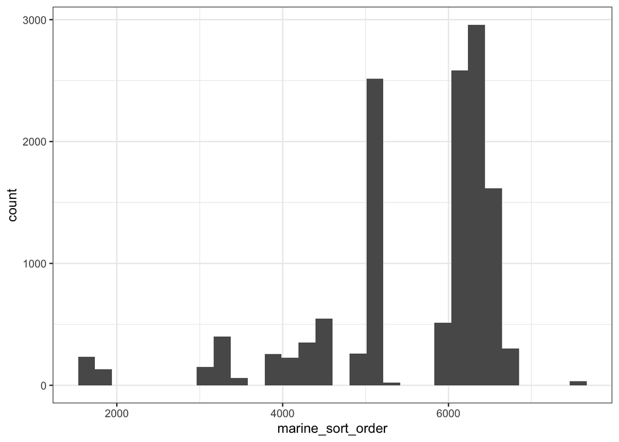

```r
SS_count18 %>% ggplot2::ggplot() + geom_histogram(aes(marine_sort_order))
```

Let me create a new data frame that will serve as a key, telling me which number corresponds to each site.

```r
unique_sites_code <- subset(SS_count18, !duplicated(SS_count18$marine_sort_order))
# skim(unique_sites_code)
# names(unique_sites_code) # want to keep columns 2, 3, 4, 5, 6
unique_sites_code1 <- unique_sites_code[c(2,3,4,5,6)]
#unique_sites_code1
numeric_sites_code_key <- unique_sites_code1
saveRDS(numeric_sites_code_key, file = "../../data/processed_data/numeric_sites_code_key.rds")
```

^^ Can use that data frame later to decode!

Next, `marine_common_season`

```r
unique(SS_count18$marine_common_season)
```

```
##  [1]  85  87  89  91  93  95  97  99 101 103 105 107 109 111 113 115 119
## [18] 121 123 125 127 129 131 133 135 137 141 143 145 147  82  86  90  94
## [35]  98 102 106 110 118 122 126 130 134 138 142 146 150  79  81  83 117
## [52] 151 114 139  78 149 152
```

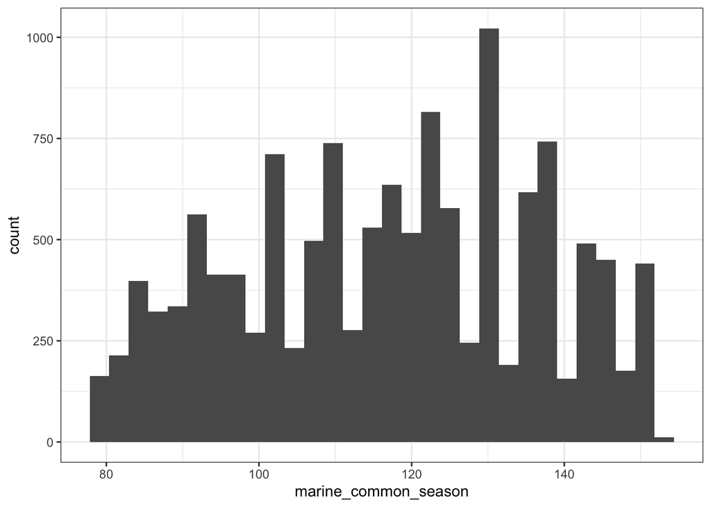

```r
SS_count18 %>% ggplot2::ggplot() + geom_histogram(aes(marine_common_season))
```

Not intuitive what this variable means, though I think I have an idea based on how they made an integer out of the sites… Lets look at the documentation. It says: “Consecutive sampling number. A code created to allow sequencing of the seasons, used for sorting data in chronological order.”

Yes, that’s pretty much what I figured. Again, lets make a key to use later.

```r
unique_seasons_code <- subset(SS_count18, !duplicated(SS_count18$marine_common_season))
# unique_seasons_code
skim(unique_seasons_code)
```

```
## Skim summary statistics
##  n obs: 57
##  n variables: 23
##
## ── Variable type:character ─────────────────────────────────────────
##      variable missing complete  n min max empty n_unique
##  species_code       0       57 57   6   6     0        2
##
## ── Variable type:factor ────────────────────────────────────────────
##               variable missing complete  n n_unique
##              bioregion       0       57 57        3
##              georegion       0       57 57        4
##             group_code       0       57 57        4
##  group_code_UCSC_other       0       57 57        2
##                 island       0       57 57        1
##     marine_season_code       0       57 57       57
##       marine_site_name       0       57 57        8
##            method_code       0       57 57        3
##   method_code_IP_other       0       57 57        2
##             mpa_region       0       57 57        5
##            season_name       0       57 57        4
##              site_code       0       57 57        8
##                  state       0       57 57        2
##                         top_counts ordered
##   Gov: 36, Oly: 19, San: 2, AK_: 0   FALSE
##    CA : 36, OR: 18, CA : 2, CA : 1   FALSE
##   UCL: 34, UCS: 20, UCS: 2, CSU: 1   FALSE
##            Oth: 37, UCS: 20, NA: 0   FALSE
##    Mai: 57, Bar: 0, Cat: 0, Hat: 0   FALSE
##     FA0: 1, FA0: 1, FA0: 1, FA0: 1   FALSE
##   Ale: 30, Cap: 17, Arr: 5, Boa: 1   FALSE
##     IP: 51, BT2: 5, GSE: 1, TS3: 0   FALSE
##              IP: 51, Oth: 6, NA: 0   FALSE
##   Sou: 36, NUL: 17, Cen: 2, Nor: 1   FALSE
##  Fal: 19, Sum: 19, Spr: 18, Win: 1   FALSE
##   ALE: 30, ARG: 17, ARH: 5, BML: 1   FALSE
##       CA: 39, OR: 18, AK: 0, WA: 0   FALSE
##
## ── Variable type:integer ───────────────────────────────────────────
##              variable missing complete  n    mean     sd   p0  p25  p50
```

[output cut: 8 more lines]

```
##   134  152 ▇▆▇▇▆▇▇▇
##  2014 2018 ▆▅▅▇▅▅▅▇
##  6420 6660 ▃▁▁▁▁▁▁▇
##     3    4 ▇▁▇▁▁▇▁▁
##    60  130 ▅▇▂▃▁▂▁▁
##     7   14 ▃▇▂▃▁▂▁▁
##     2    8 ▇▃▁▁▁▁▁▁
##
## ── Variable type:numeric ───────────────────────────────────────────
##   variable missing complete  n    mean   sd      p0     p25     p50
##   latitude       0       57 57   37.33 4.17   33.57   34.47   34.47
##  longitude       0       57 57 -121.58 1.99 -124.4  -124.4  -120.28
##      p75    p100     hist
##    43.31   44.24 ▇▁▁▁▁▁▁▃
##  -120.28 -117.84 ▅▁▁▁▁▇▁▁
```

```r
# pretty sure this can be coded by `marine_season_code` column.
# names(unique_seasons_code) # want to keep columns 7 and 8
unique_seasons_code1 <- unique_seasons_code[c(7,8)]
numeric_seasons_code_key <- unique_seasons_code1

saveRDS(numeric_seasons_code_key, file = "../../data/processed_data/numeric_seasons_code_key.rds")
```

Next, `marine_common_year`

```r
unique(SS_count18$marine_common_year)
```

```
##  [1] 2002 2003 2004 2005 2006 2007 2008 2009 2010 2011 2012 2013 2014 2015
## [15] 2016 2017 2001 2018 2000
```

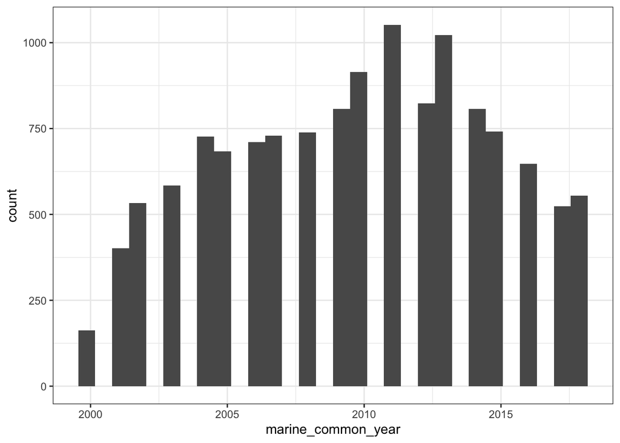

```r
SS_count18 %>% ggplot2::ggplot() + geom_histogram(aes(marine_common_year))
```

Next, `season_sequence`

```r
#SS_count <- SS_count
unique(SS_count18$season_sequence)
```

```
## [1] 1 3 2 4
```

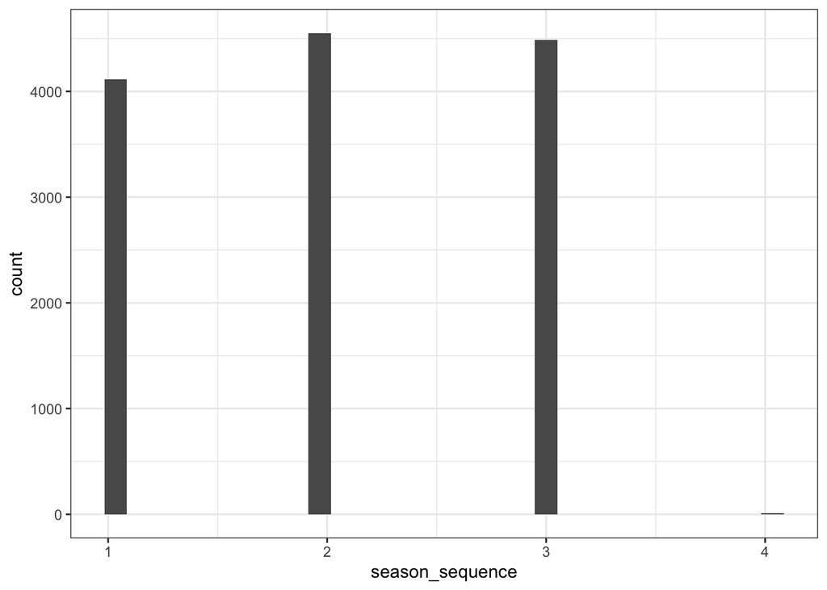

```r
SS_count18 %>% ggplot2::ggplot() + geom_histogram(aes(season_sequence))
```

Another way of describing season. Lets make a key.

```r
unique_season_sequence <- subset(SS_count18, !duplicated(SS_count18$season_sequence))
#unique_season_sequence
#names(unique_season_sequence) # want to keep columns 10 and 11
unique_season_sequence1 <- unique_season_sequence[c(10,11)]
season_sequence_key <- unique_season_sequence1

saveRDS(season_sequence_key, file = "../../data/processed_data/season_sequence_key.rds")
```

Next, `species_code`

```r
#SS_count <- SS_count
unique(SS_count18$species_code)
```

```
## [1] "PISOCH" "KATTUN" "EVATRO"
```

```r
# wait, this should absolutely be a factor, not an integer?
typeof(SS_count18$species_code)
```

```
## [1] "character"
```

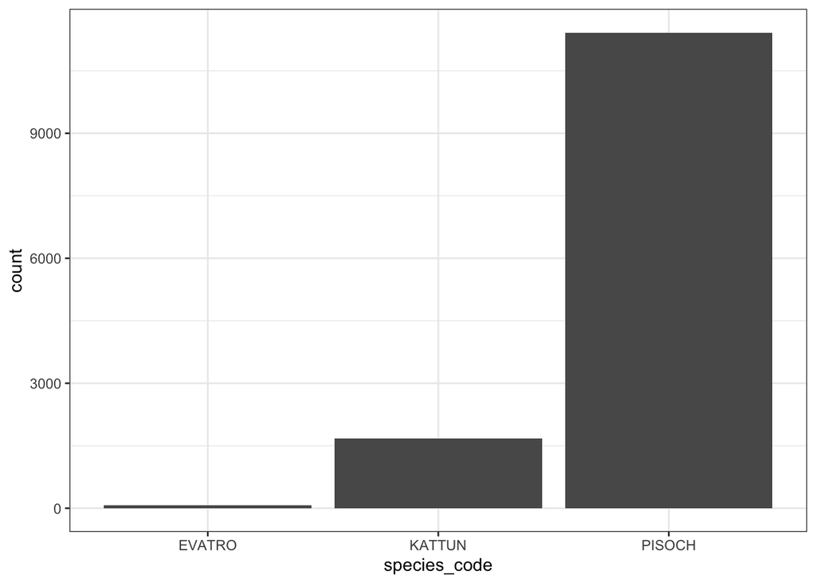

```r
# Oh, it is a character. Somehow I missed this going through the characters(turned factors), but my numbering will mess up if I put it up there. Just dealing with it here.
SS_count18 %>% ggplot2::ggplot() + geom_bar(aes(species_code))
```

Two things:  
* Change names to just be the actual species names.. this isn’t saving that much space and the all-caps is annoying me. * Very skewed towards PISOCH. Make a new variable that is PISOCH vs other.

Changing names

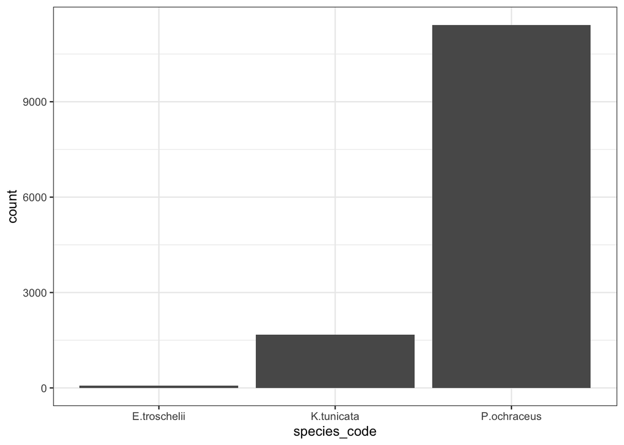

```r
SS_count19 <- SS_count18
SS_count19 <- SS_count19 %>% mutate(species_code = recode(species_code, "PISOCH" = "P.ochraceus", "KATTUN" = "K.tunicata", "EVATRO" = "E.troschelii"))
SS_count19$species_code <- as.factor(SS_count19$species_code)
SS_count19 %>% ggplot2::ggplot() + geom_bar(aes(species_code))
```

Actually, regarding that second point… in looking up the species names associated with the above species codes, I discovered K. tunicata is actually a chiton… I honestly had no idea! I thought (assumed) all three spp. were sea stars. It doesn’t make biological sense to group E.troschelii and K.tunicata together as “other” when E.troschelii and P. ochraceus have more in common biologically… and making a new group of all sea stars vs not sea stars will just make the data more skewed… thus, I’m not going to partition this variable any more.

Next, `size_sort_order`

```r
unique(SS_count19$size_sort_order)
```

```
##  [1]  3  4  5  6  7  8  9 10 11 12 14 15 16 19 20 13 17 18 21 23  2  1 24
## [24] 22 26 27 28 29 30 31 32 33
```

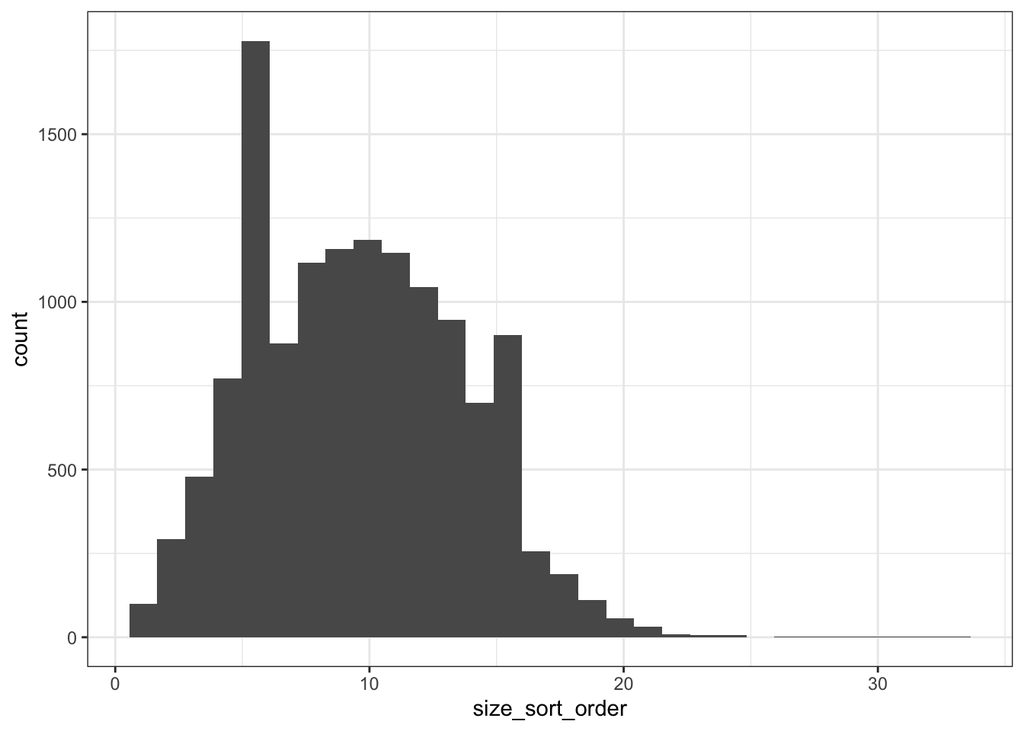

```r
SS_count19 %>% ggplot2::ggplot() + geom_histogram(aes(size_sort_order))
```

What does this variable mean again? Documentation for `size_sort_order` says: “Numerical code used for sorting size_bin” …and for `size_bin` it says: “The size of the species being counted, binned to the nearest 5 or 10 millimeter.”

Okay lets skip ahead and look at `size_bin`

```r
#SS_count <- SS_count
unique(SS_count19$size_bin)
```

```
##  [1]  20  30  40  50  60  70  80  90 100 110 130 140 150 180 190 120 160
## [18] 170 200 220  10  15  25  35   5 230 210 250 260 270 280 290 300 310
## [35] 320
```

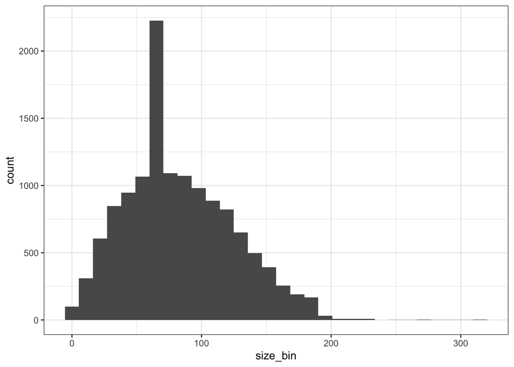

```r
SS_count19 %>% ggplot2::ggplot() + geom_histogram(aes(size_bin))
```

Okay… but this is likely to vary A LOT by species (prior knowledge tells me E.troschelii is, on average, way smaller than P.ochraceus)

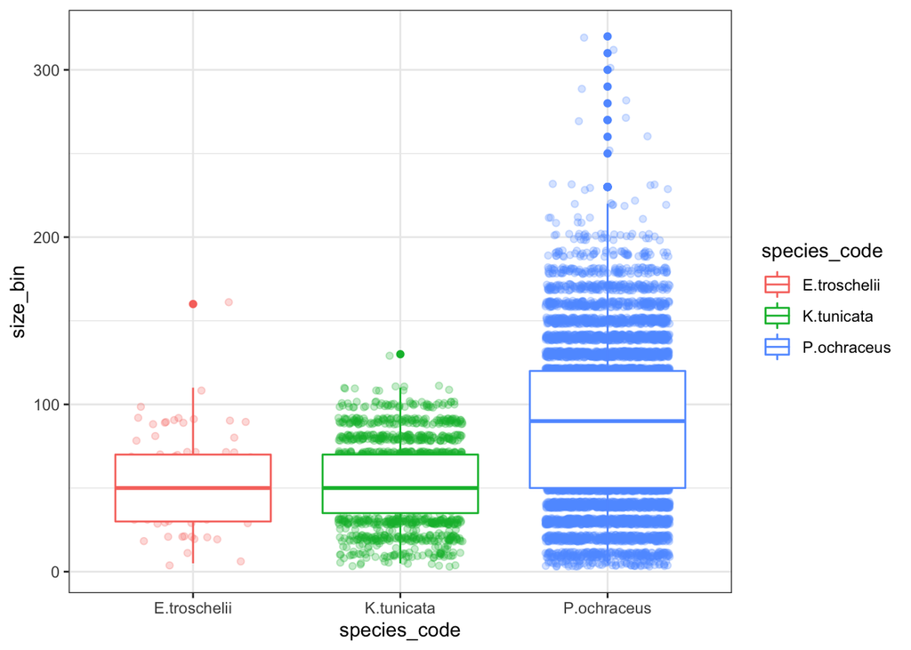

```r
SS_count19 %>% ggplot(aes(species_code, size_bin, col = species_code)) + geom_jitter(width = 0.3, alpha = 0.25) + geom_boxplot()
```

Just as I suspected- the sizes aren’t similar among species. If my model analyzes size_bin and there is an effect of size but only in P.ochraceus, won’t all the low values for the other two species mess with that when not accounting for interactions between these two variables?

I’m going move on, but will keep this in mind…. I may end up re-running my models on P.ochraceus data only, as its really what I’m interested in.. but we’ll see.

Oh- and both `size_sort_order` and `size_bin` look good.

Next, `total`

```r
unique(SS_count19$total)
```

```
##   [1]   1   3  16  25  27  22  11   2   6   9  14  29  46  28  21   5   4
##  [18]   8  18  30  17  15   7  10  13  12  20  24  23  19  26  32  39  34
##  [35]  33  35  52  50  49  37  64  53  68  45  31  71 121  75  42  94 151
##  [52] 100  41  77 105  88  36  43  40  38  47  57  63  76  67  51  48  69
##  [69]  80  56 116 131  66  87 111  95 175 212 177 117  93  85 102 106  60
##  [86]  55  92 115  58  79 118  74  91  86  44  59  62  78  70 155 144  82
## [103]  96 137  65  61  54  73  72  84 189 160  89 203 222  90 162 107 136
## [120] 138 147 110 120  81 174 166 184 335 252 108 239 135 304 190 360 167
## [137] 181  83  97 133 149 109 103
```

```r
summary(SS_count19$total)
```

```
##    Min. 1st Qu.  Median    Mean 3rd Qu.    Max.
##   1.000   2.000   4.000   9.919  11.000 360.000
```

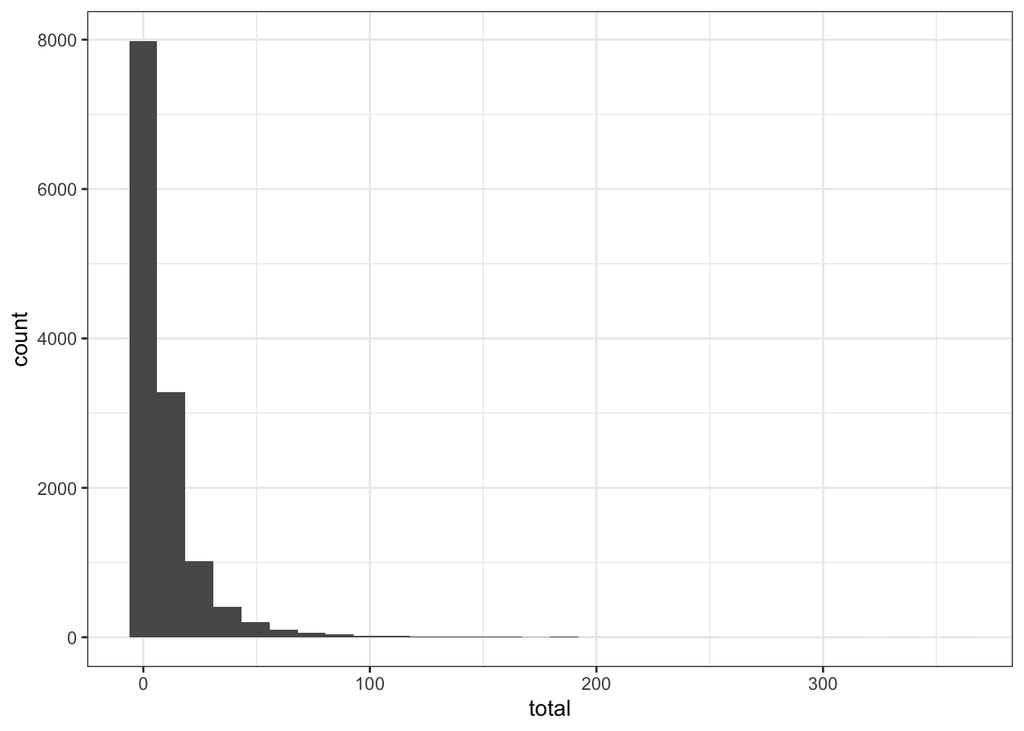

```r
SS_count19 %>% ggplot2::ggplot() + geom_histogram(aes(total))
```

Looks good to me. This is the shape I would expect of an abundance distribution.

## Doubles/Numeric

`latitude` & `longitude` are the only two numeric variables

```r
unique(SS_count19$latitude)
```

```
##  [1] 34.46714 43.30894 34.47344 38.95550 38.31820 34.55388 44.24456
##  [8] 38.31040 42.22814 34.38703 35.44739 37.99383 34.40693 33.57078
## [15] 33.45145 33.38499 33.45990 37.02208 38.74051 41.65249 41.69000
## [22] 45.91809 41.59476 44.83864 48.15049 36.46904 38.56614 34.44334
## [29] 47.30255 48.52221 48.52353 35.28966 47.62842 36.62120 57.02250
## [36] 39.60412 48.39147 34.71880 47.57688 35.97965 40.34100 38.88091
## [43] 36.28061 34.35548 36.94915 34.88122 34.06612 35.66493 34.01201
## [50] 38.58585 36.63796 56.98661 48.71200 35.72883 33.70679 36.51366
## [57] 33.74101 57.04870 38.86138 48.53710 48.53430 32.87165 37.04425
## [64] 38.73050 35.16881 33.54477 40.02254 35.60414 36.44787 34.73038
## [71] 38.93787 36.56087 36.94841 33.51335 33.71539 38.52394
```

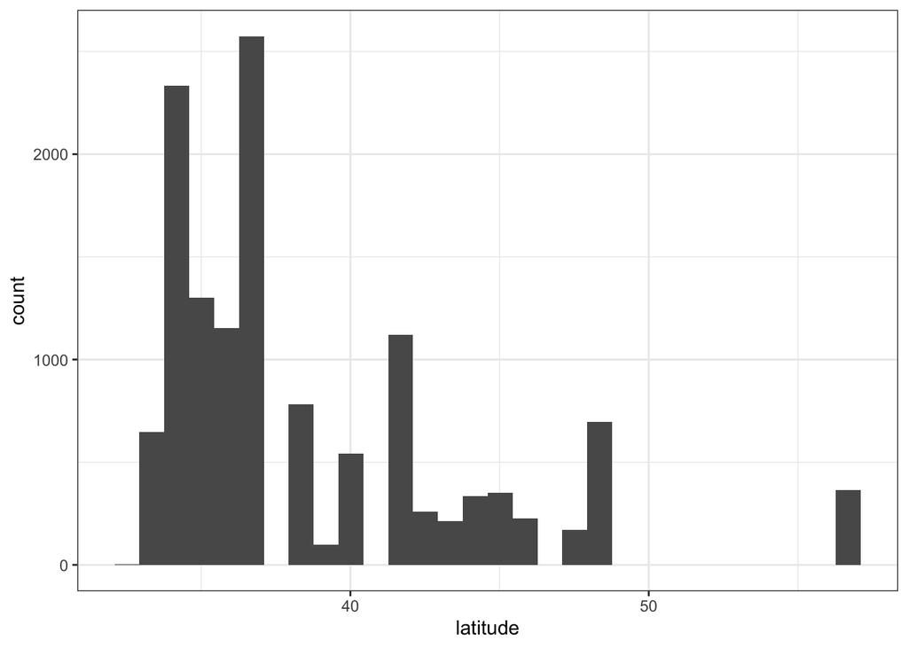

```r
SS_count19 %>% ggplot2::ggplot() + geom_histogram(aes(latitude))
```

Longitude

```r
unique(SS_count19$longitude)
```

```
##  [1] -120.2774 -124.4008 -120.1454 -123.7413 -123.0737 -120.6117 -124.1144
##  [8] -123.0824 -124.3879 -119.5141 -120.9498 -122.9673 -119.8780 -117.8377
## [15] -118.4876 -118.4752 -117.7147 -122.2154 -123.5109 -124.1278 -124.1426
## [22] -123.9803 -124.1064 -124.0588 -123.6370 -121.9344 -123.3292 -120.4565
## [29] -124.2753 -122.5435 -122.5522 -120.8833 -122.9503 -121.9073 -135.3539
## [36] -123.7889 -124.6537 -120.6088 -122.5441 -121.4903 -124.3632 -123.6748
## [43] -121.8632 -119.4407 -122.0611 -120.6395 -118.9978 -121.2870 -118.7922
## [50] -123.3415 -121.9376 -135.3776 -122.5191 -121.3187 -118.2860 -121.9469
## [57] -118.4095 -135.3231 -123.6536 -122.5547 -122.5549 -117.2533 -122.2349
## [64] -123.4886 -120.6967 -117.7994 -124.0737 -121.1423 -121.9287 -120.6155
## [71] -123.7288 -121.9405 -122.0646 -117.7579 -118.3196 -122.1038 -123.2675
```

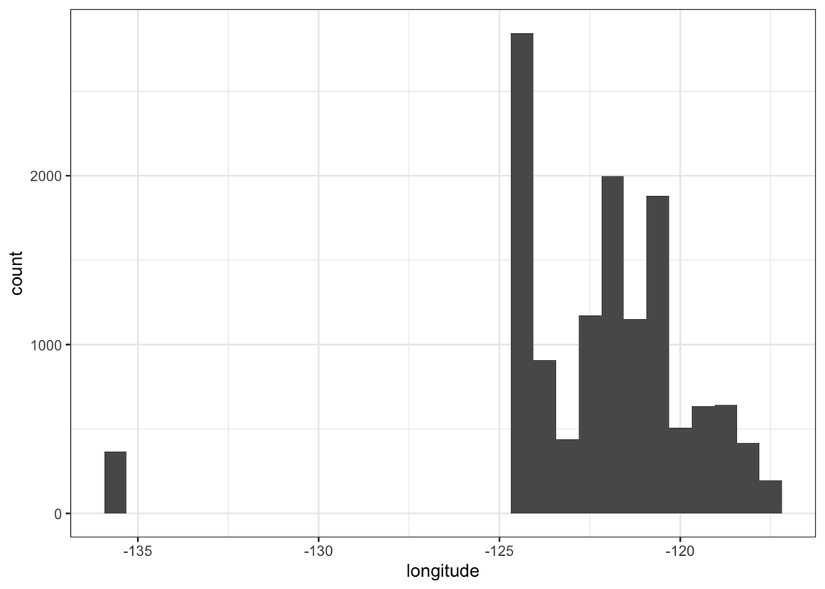

```r
SS_count19 %>% ggplot2::ggplot() + geom_histogram(aes(longitude))
```

Okay, everything looks good!

Lets take a final look, then rename and save the data.

```r
clean_data <- SS_count19
skim(clean_data)
```

```
## Skim summary statistics
##  n obs: 13165
##  n variables: 23
##
## ── Variable type:factor ────────────────────────────────────────────
##               variable missing complete     n n_unique
##              bioregion       0    13165 13165        6
##              georegion       0    13165 13165        9
##             group_code       0    13165 13165        9
##  group_code_UCSC_other       0    13165 13165        2
##                 island       0    13165 13165        6
##     marine_season_code       0    13165 13165       57
##       marine_site_name       0    13165 13165       77
##            method_code       0    13165 13165        4
##   method_code_IP_other       0    13165 13165        2
##             mpa_region       0    13165 13165        6
##            season_name       0    13165 13165        4
##              site_code       0    13165 13165       77
##           species_code       0    13165 13165        3
##                  state       0    13165 13165        4
##                                              top_counts ordered
##   San: 5608, Oly: 4138, Gov: 2366, Sal: 652               FALSE
##   CA : 5382, CA : 2592, CA : 1660, OR: 1386               FALSE
##    UCS: 9657, UCL: 2032, PBN: 400, SSS: 366               FALSE
##                 UCS: 9657, Oth: 3508, NA: 0               FALSE
##    Mai: 12364, Bar: 279, Sad: 250, Hat: 150               FALSE
##      SU1: 440, SU1: 403, SU1: 392, FA1: 376               FALSE
##      Mil: 524, Sco: 513, Sti: 472, End: 468               FALSE
##      IP: 12012, BT2: 782, GSE: 336, TS3: 35               FALSE
##                 IP: 12012, Oth: 1153, NA: 0               FALSE
##  Cen: 5382, Sou: 2627, NUL: 1932, Nor: 1660               FALSE
##    Sum: 4552, Fal: 4489, Spr: 4112, Win: 12               FALSE
##      MCR: 524, SCT: 513, SWC: 472, END: 468               FALSE
##                                           P.o: 11416, K   FALSE
##       CA: 10548, OR: 1386, WA: 865, AK: 366               FALSE
##
## ── Variable type:integer ───────────────────────────────────────────
##              variable missing complete     n    mean      sd   p0  p25
##  marine_common_season       0    13165 13165  116.82   19.23   78  101
##    marine_common_year       0    13165 13165 2009.7     4.81 2000 2006
##     marine_sort_order       0    13165 13165 5566.24 1125.15 1720 5020
##       season_sequence       0    13165 13165    2.03    0.81    1    1
##              size_bin       0    13165 13165   82.44   42.2     5   50
##       size_sort_order       0    13165 13165    9.57    4.15    1    6
##                 total       0    13165 13165    9.92   16.43    1    2
##   p50  p75 p100     hist
##   118  131  152 ▅▅▆▇▇▇▇▅
##  2010 2013 2018 ▃▅▅▇▇▆▆▆
##  6090 6370 7650 ▁▁▁▂▃▃▇▁
##     2    3    4 ▇▁▇▁▁▇▁▁
##    80  110  320 ▅▇▇▃▁▁▁▁
##    10   12   33 ▅▇▇▃▁▁▁▁
##     4   11  360 ▇▁▁▁▁▁▁▁
##
## ── Variable type:numeric ───────────────────────────────────────────
##   variable missing complete     n    mean   sd      p0     p25     p50
##   latitude       0    13165 13165   38.67 5.2    32.87   34.73   36.62
##  longitude       0    13165 13165 -122.25 2.86 -135.38 -123.98 -121.94
##      p75    p100     hist
##    41.65   57.05 ▇▆▃▂▁▁▁▁
##  -120.62 -117.25 ▁▁▁▁▅▇▆▃
```

Save the data as an RDS.

```r
saveRDS(clean_data, file = "../../data/processed_data/processeddata.rds")
```